# Machine Learning Course Project

Oleh Tovkach

1/1/2018

In this course project, we use the Weight Lifting Exercise Dataset (available at http://groupware.les.inf.puc-rio.br/har) to build a random forest model that predicts how well a person performs dumbell lifts.

#### Data

According to the original paper Velloso (2013), six participants were asked to perform dumbbell lifts in five different manners: correctly (class A) and incorrectly (classes B, C, D, E). Measurements from accelerometers mounted on the participants’ belts, gloves, armbands and dumbbels are stored in the Weight Lifting Exercise Dataset (available at http://groupware.les.inf.puc-rio.br/har).

```r
if (!file.exists("./data.csv")) {
  download.file("http://d396qusza40orc.cloudfront.net/predmachlearn/pml-training.csv",
                destfile = "./data.csv", method = "curl")
}
df <- read.csv("data.csv", header=TRUE, stringsAsFactors=TRUE,
                     na.strings=c("", "NA"))  # read strings as factors and empty cells as NAs
```

Technically, the data set has the following structure.

```r
str(df, list.len = 10)  # only show first 10 columns
```

```
## 'data.frame':    19622 obs. of  160 variables:
##  $ X                       : int  1 2 3 4 5 6 7 8 9 10 ...
##  $ user_name               : Factor w/ 6 levels "adelmo","carlitos",..: 2 2 2 2 2 2 2 2 2 2 ...
##  $ raw_timestamp_part_1    : int  1323084231 1323084231 1323084231 1323084232 1323084232 1323084232 1323084232 1323084232 1323084232 1323084232 ...
##  $ raw_timestamp_part_2    : int  788290 808298 820366 120339 196328 304277 368296 440390 484323 484434 ...
##  $ cvtd_timestamp          : Factor w/ 20 levels "02/12/2011 13:32",..: 9 9 9 9 9 9 9 9 9 9 ...
##  $ new_window              : Factor w/ 2 levels "no","yes": 1 1 1 1 1 1 1 1 1 1 ...
##  $ num_window              : int  11 11 11 12 12 12 12 12 12 12 ...
##  $ roll_belt               : num  1.41 1.41 1.42 1.48 1.48 1.45 1.42 1.42 1.43 1.45 ...
##  $ pitch_belt              : num  8.07 8.07 8.07 8.05 8.07 8.06 8.09 8.13 8.16 8.17 ...
##  $ yaw_belt                : num  -94.4 -94.4 -94.4 -94.4 -94.4 -94.4 -94.4 -94.4 -94.4 -94.4 ...
##   [list output truncated]
```

It is a data frame with 19622 observations of 160 variables. A closer inspection reveals that columns 1 to 7 user/participant name, timestamps, etc. Although it may be an oversimplification, this study is not going to take into account possible time effects. Hence, we omit those columns as redundant.

```r
df <- df[, -c(1:7)]
```

Unfortunately, the updated `df` is not perfect in the sense of missing values

```r
naCols <- apply(df, 2, function(x) any(is.na(x)))
table(naCols)
```

```
## naCols
## FALSE  TRUE
##    53   100
```

100 of 153 columns have at lest one NA cell. For simplicity we remove all ``incomplete’’ variables as well.

```r
df <- df[, naCols == FALSE]
dim(df)
```

```
## [1] 19622    53
```

Thus, we end up with 19622 observations of 53 variables – 52 potential predictors and one dependent variable `classe` (factor with five levels). By means of the `nearZeroVar` from the `caret` package one can ensure that all the 53 variables have non-zero variance, i.e. are not constant.

#### Model

Let us start our modelling by splitting the data into training and testing subsets, `traindf` and `testdf`, respectively.

```r
set.seed(99)
library(caret)
inTrain <- createDataPartition(df$classe, p = 0.7, list = FALSE)  # traindf = 70% of data
traindf <- df[inTrain, ]
testdf <- df[-inTrain, ]
```

Given the specifics of our problem, the random forest seems like a suitable method. We use all the variables, except for `classe`, as predictors and by trials and errors find that the model with 99 trees (`ntree = 99`) and $\sqrt{52}\approx7$ splitting variables at each tree node (`mtry = 7`) provides a reasonable balance between computational time and accuracy.

```r
fitControl <- trainControl(method = "cv", number = 5) # use 5-fold cross-validation
model <- train(classe ~ ., data = traindf, ntree = 99, trControl = fitControl,
               tuneGrid = data.frame(.mtry = 7))
model
```

```
## Random Forest
##
## 13737 samples
##    52 predictor
##     5 classes: 'A', 'B', 'C', 'D', 'E'
##
## No pre-processing
## Resampling: Cross-Validated (5 fold)
## Summary of sample sizes: 10988, 10990, 10989, 10990, 10991
## Resampling results:
##
##   Accuracy   Kappa
##   0.9925745  0.9906066
##
## Tuning parameter 'mtry' was held constant at a value of 7
```

Note that we resort to the 5-fold cross-validation resampling technique instead of the default bootstraping in order to improve perfomance. The error rate vs. number of trees plot shown below confirms that at `ntree = 99` the error of the model is relatively small $(< 0.02)$ and roughly constant.

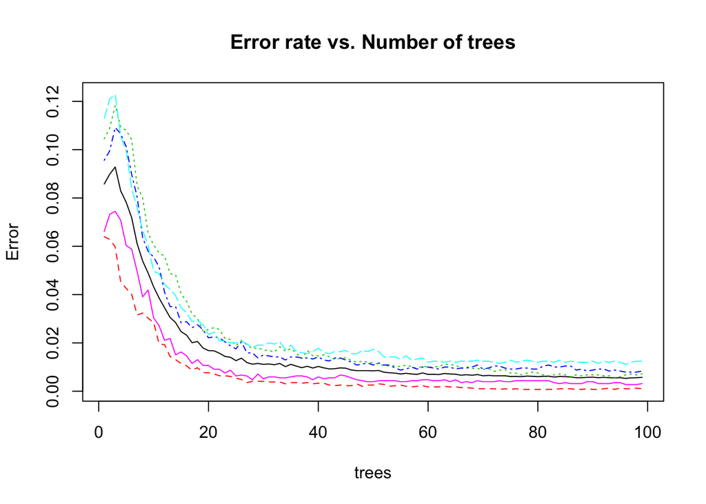

```r
plot(model$finalModel, main = "Error rate vs. Number of trees")
```

```r
confusionMatrix(testdf$classe, predict(model, newdata = testdf))$overall
```

```
##       Accuracy          Kappa  AccuracyLower  AccuracyUpper   AccuracyNull
##      0.9928632      0.9909715      0.9903653      0.9948517      0.2856415
## AccuracyPValue  McnemarPValue
##      0.0000000            NaN
```

#### Actual prediction

Now let us apply our model to the actual testing data set provided by the Coursera team

```r
if (!file.exists("./testing.csv")) {
  download.file("http://d396qusza40orc.cloudfront.net/predmachlearn/pml-testing.csv",
                destfile = "./testing.csv", method = "curl")
}
testing <- read.csv("testing.csv", header=TRUE, stringsAsFactors=TRUE,
                     na.strings=c("", "NA"))  # read strings as factors and empty cells as NAs
testing <- testing[, names(testing) %in% names(traindf)]  # only subset features of the model
predict(model, newdata = testing)
```

```
##  [1] B A B A A E D B A A B C B A E E A B B B
## Levels: A B C D E
```

#### References

Velloso, Eduardo *et al*. 2013. “Qualitative Activity Recognition of Weight Lifting Exercises.” *Proceedings of the 4th Augmented Human International Conference*. ACM, 116–23. http://groupware.les.inf.puc-rio.br/har.